# Risk Factor Analysis

## Outcome Variable

**Outcome Variable:** whz

## Predictor Variables

**Intervention Variable:** nhh

**Adjustment Set:**

- arm
- W_mage
- meducyrs
- feducyrs
- hhwealth_quart
- W_mhtcm
- W_mwtkg
- W_mbmi
- W_nrooms
- cleanck
- impfloor
- impsan
- safeh20
- delta_W_mage
- delta_meducyrs
- delta_feducyrs
- delta_hhwealth_quart
- delta_W_mhtcm
- delta_W_mwtkg
- delta_W_mbmi
- delta_W_nrooms
- delta_cleanck
- delta_impfloor
- delta_impsan
- delta_safeh20

## Stratifying Variables

The analysis was stratified on these variable(s):

- agecat
- studyid
- country

## Data Summary

| agecat | studyid | country | nhh | n_cell | n |
| --- | --- | --- | --- | --- | --- |
| Birth | IRC | INDIA | 3 or less | 52 | 343 |
| Birth | IRC | INDIA | 4-5 | 131 | 343 |
| Birth | IRC | INDIA | 6-7 | 84 | 343 |
| Birth | IRC | INDIA | 8+ | 76 | 343 |
| Birth | NIH-Birth | BANGLADESH | 3 or less | 104 | 575 |
| Birth | NIH-Birth | BANGLADESH | 4-5 | 244 | 575 |
| Birth | NIH-Birth | BANGLADESH | 6-7 | 130 | 575 |
| Birth | NIH-Birth | BANGLADESH | 8+ | 97 | 575 |
| Birth | NIH-Crypto | BANGLADESH | 3 or less | 103 | 707 |
| Birth | NIH-Crypto | BANGLADESH | 4-5 | 318 | 707 |
| Birth | NIH-Crypto | BANGLADESH | 6-7 | 167 | 707 |
| Birth | NIH-Crypto | BANGLADESH | 8+ | 119 | 707 |
| Birth | PROVIDE | BANGLADESH | 3 or less | 103 | 532 |
| Birth | PROVIDE | BANGLADESH | 4-5 | 249 | 532 |
| Birth | PROVIDE | BANGLADESH | 6-7 | 114 | 532 |
| Birth | PROVIDE | BANGLADESH | 8+ | 66 | 532 |
| 6 months | IRC | INDIA | 3 or less | 57 | 408 |
| 6 months | IRC | INDIA | 4-5 | 157 | 408 |
| 6 months | IRC | INDIA | 6-7 | 107 | 408 |
| 6 months | IRC | INDIA | 8+ | 87 | 408 |
| 6 months | LCNI-5 | MALAWI | 3 or less | 224 | 816 |
| 6 months | LCNI-5 | MALAWI | 4-5 | 340 | 816 |
| 6 months | LCNI-5 | MALAWI | 6-7 | 182 | 816 |
| 6 months | LCNI-5 | MALAWI | 8+ | 70 | 816 |
| 6 months | NIH-Birth | BANGLADESH | 3 or less | 95 | 537 |
| 6 months | NIH-Birth | BANGLADESH | 4-5 | 227 | 537 |
| 6 months | NIH-Birth | BANGLADESH | 6-7 | 128 | 537 |
| 6 months | NIH-Birth | BANGLADESH | 8+ | 87 | 537 |
| 6 months | NIH-Crypto | BANGLADESH | 3 or less | 104 | 715 |
| 6 months | NIH-Crypto | BANGLADESH | 4-5 | 326 | 715 |
| 6 months | NIH-Crypto | BANGLADESH | 6-7 | 170 | 715 |
| 6 months | NIH-Crypto | BANGLADESH | 8+ | 115 | 715 |
| 6 months | PROVIDE | BANGLADESH | 3 or less | 105 | 603 |
| 6 months | PROVIDE | BANGLADESH | 4-5 | 289 | 603 |
| 6 months | PROVIDE | BANGLADESH | 6-7 | 130 | 603 |
| 6 months | PROVIDE | BANGLADESH | 8+ | 79 | 603 |
| 6 months | SAS-FoodSuppl | INDIA | 3 or less | 33 | 380 |
| 6 months | SAS-FoodSuppl | INDIA | 4-5 | 166 | 380 |
| 6 months | SAS-FoodSuppl | INDIA | 6-7 | 115 | 380 |
| 6 months | SAS-FoodSuppl | INDIA | 8+ | 66 | 380 |
| 24 months | IRC | INDIA | 3 or less | 58 | 409 |
| 24 months | IRC | INDIA | 4-5 | 158 | 409 |
| 24 months | IRC | INDIA | 6-7 | 107 | 409 |
| 24 months | IRC | INDIA | 8+ | 86 | 409 |
| 24 months | LCNI-5 | MALAWI | 3 or less | 157 | 558 |
| 24 months | LCNI-5 | MALAWI | 4-5 | 230 | 558 |
| 24 months | LCNI-5 | MALAWI | 6-7 | 123 | 558 |
| 24 months | LCNI-5 | MALAWI | 8+ | 48 | 558 |
| 24 months | NIH-Birth | BANGLADESH | 3 or less | 74 | 428 |
| 24 months | NIH-Birth | BANGLADESH | 4-5 | 184 | 428 |
| 24 months | NIH-Birth | BANGLADESH | 6-7 | 100 | 428 |
| 24 months | NIH-Birth | BANGLADESH | 8+ | 70 | 428 |
| 24 months | NIH-Crypto | BANGLADESH | 3 or less | 69 | 514 |
| 24 months | NIH-Crypto | BANGLADESH | 4-5 | 232 | 514 |
| 24 months | NIH-Crypto | BANGLADESH | 6-7 | 130 | 514 |
| 24 months | NIH-Crypto | BANGLADESH | 8+ | 83 | 514 |
| 24 months | PROVIDE | BANGLADESH | 3 or less | 106 | 579 |
| 24 months | PROVIDE | BANGLADESH | 4-5 | 273 | 579 |
| 24 months | PROVIDE | BANGLADESH | 6-7 | 117 | 579 |
| 24 months | PROVIDE | BANGLADESH | 8+ | 83 | 579 |

The following strata were considered:

- agecat: 24 months, studyid: IRC, country: INDIA
- agecat: 24 months, studyid: LCNI-5, country: MALAWI
- agecat: 24 months, studyid: NIH-Birth, country: BANGLADESH
- agecat: 24 months, studyid: NIH-Crypto, country: BANGLADESH
- agecat: 24 months, studyid: PROVIDE, country: BANGLADESH
- agecat: 6 months, studyid: IRC, country: INDIA
- agecat: 6 months, studyid: LCNI-5, country: MALAWI
- agecat: 6 months, studyid: NIH-Birth, country: BANGLADESH
- agecat: 6 months, studyid: NIH-Crypto, country: BANGLADESH
- agecat: 6 months, studyid: PROVIDE, country: BANGLADESH
- agecat: 6 months, studyid: SAS-FoodSuppl, country: INDIA
- agecat: Birth, studyid: IRC, country: INDIA
- agecat: Birth, studyid: NIH-Birth, country: BANGLADESH
- agecat: Birth, studyid: NIH-Crypto, country: BANGLADESH
- agecat: Birth, studyid: PROVIDE, country: BANGLADESH

## Methods Detail

We’re interested in the causal parameters $E[Y_a]$ for all values of $a \in \mathcal{A}$. These parameters represent the mean outcome if, possibly contrary to fact, we intervened to set all units to have $A=a$. Under the randomization and positivity assumptions, these are identified by the statistical parameters $\psi_a=E_W[E_{Y|A,W}(Y|A=a,W)]$. In addition, we’re interested in the mean of $Y$, $E[Y]$ under no intervention (the observed mean). We will estimate these parameters by using SuperLearner to fit the relevant likelihood factors – $E_{Y|A,W}(Y|A=a,W)$ and $p(A=a|W)$, and then updating our likelihood fit using a joint TMLE.

For unadjusted analyses ($W=\{\}$), initial likelihoods were estimated using Lrnr_glm to estimate the simple $E(Y|A)$ and Lrnr_mean to estimate $p(A)$. For adjusted analyses, a small library containing Lrnr_glmnet, Lrnr_xgboost, and Lrnr_mean was used.

Having estimated these parameters, we will then use the delta method to estimate relative risks and attributable risks relative to a prespecified baseline level of $A$.

# Results Detail

## Results Plots

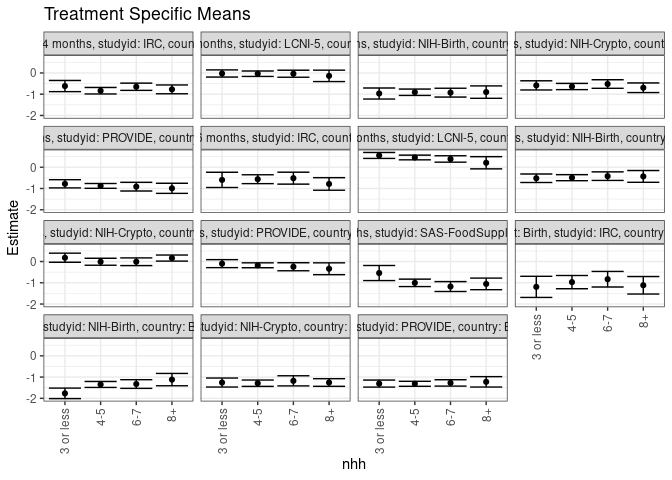

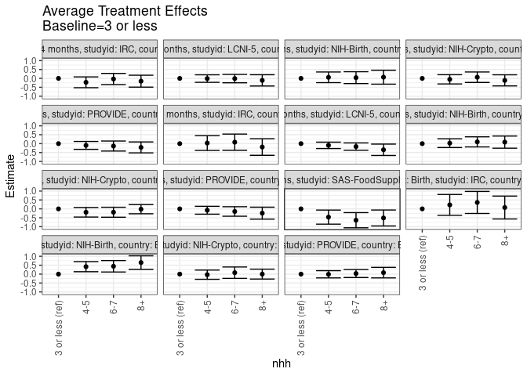

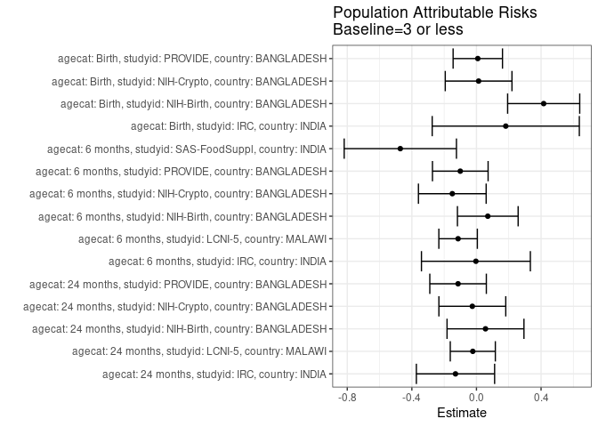

## Results Table

### Parameter: TSM

| agecat | studyid | country | intervention_level | baseline_level | estimate | ci_lower | ci_upper |
| --- | --- | --- | --- | --- | --- | --- | --- |
| Birth | IRC | INDIA | 3 or less | NA | -1.1920093 | -1.6900987 | -0.6939199 |
| Birth | IRC | INDIA | 4-5 | NA | -0.9686767 | -1.2792991 | -0.6580543 |
| Birth | IRC | INDIA | 6-7 | NA | -0.8313385 | -1.1978924 | -0.4647847 |
| Birth | IRC | INDIA | 8+ | NA | -1.1167785 | -1.5283221 | -0.7052350 |
| Birth | NIH-Birth | BANGLADESH | 3 or less | NA | -1.7660595 | -2.0123607 | -1.5197583 |
| Birth | NIH-Birth | BANGLADESH | 4-5 | NA | -1.3473103 | -1.4882075 | -1.2064131 |
| Birth | NIH-Birth | BANGLADESH | 6-7 | NA | -1.3267839 | -1.5304408 | -1.1231270 |
| Birth | NIH-Birth | BANGLADESH | 8+ | NA | -1.1188843 | -1.4091714 | -0.8285973 |
| Birth | NIH-Crypto | BANGLADESH | 3 or less | NA | -1.2574535 | -1.4696286 | -1.0452783 |
| Birth | NIH-Crypto | BANGLADESH | 4-5 | NA | -1.2892905 | -1.4392829 | -1.1392982 |
| Birth | NIH-Crypto | BANGLADESH | 6-7 | NA | -1.1765723 | -1.4154761 | -0.9376685 |
| Birth | NIH-Crypto | BANGLADESH | 8+ | NA | -1.2562383 | -1.4357231 | -1.0767536 |
| Birth | PROVIDE | BANGLADESH | 3 or less | NA | -1.3067616 | -1.4725492 | -1.1409740 |
| Birth | PROVIDE | BANGLADESH | 4-5 | NA | -1.3162615 | -1.4340158 | -1.1985073 |
| Birth | PROVIDE | BANGLADESH | 6-7 | NA | -1.2742300 | -1.4238975 | -1.1245624 |
| Birth | PROVIDE | BANGLADESH | 8+ | NA | -1.2235137 | -1.4682083 | -0.9788190 |
| 6 months | IRC | INDIA | 3 or less | NA | -0.5954882 | -0.9541254 | -0.2368510 |
| 6 months | IRC | INDIA | 4-5 | NA | -0.5624512 | -0.7702897 | -0.3546128 |
| 6 months | IRC | INDIA | 6-7 | NA | -0.5142380 | -0.7951239 | -0.2333521 |
| 6 months | IRC | INDIA | 8+ | NA | -0.7860282 | -1.0813107 | -0.4907456 |
| 6 months | LCNI-5 | MALAWI | 3 or less | NA | 0.5554973 | 0.4155939 | 0.6954006 |
| 6 months | LCNI-5 | MALAWI | 4-5 | NA | 0.4595646 | 0.3487039 | 0.5704254 |
| 6 months | LCNI-5 | MALAWI | 6-7 | NA | 0.3895058 | 0.2380070 | 0.5410046 |
| 6 months | LCNI-5 | MALAWI | 8+ | NA | 0.2110031 | -0.0761556 | 0.4981618 |
| 6 months | NIH-Birth | BANGLADESH | 3 or less | NA | -0.5175555 | -0.7170753 | -0.3180357 |
| 6 months | NIH-Birth | BANGLADESH | 4-5 | NA | -0.4909574 | -0.6330597 | -0.3488551 |
| 6 months | NIH-Birth | BANGLADESH | 6-7 | NA | -0.4190658 | -0.6209963 | -0.2171353 |
| 6 months | NIH-Birth | BANGLADESH | 8+ | NA | -0.4321853 | -0.7092026 | -0.1551680 |
| 6 months | NIH-Crypto | BANGLADESH | 3 or less | NA | 0.1793813 | -0.0346045 | 0.3933671 |
| 6 months | NIH-Crypto | BANGLADESH | 4-5 | NA | -0.0103654 | -0.1743486 | 0.1536178 |
| 6 months | NIH-Crypto | BANGLADESH | 6-7 | NA | -0.0095936 | -0.1908564 | 0.1716693 |
| 6 months | NIH-Crypto | BANGLADESH | 8+ | NA | 0.1634809 | 0.0203013 | 0.3066606 |
| 6 months | PROVIDE | BANGLADESH | 3 or less | NA | -0.0988992 | -0.2877012 | 0.0899028 |
| 6 months | PROVIDE | BANGLADESH | 4-5 | NA | -0.1768720 | -0.2920184 | -0.0617256 |
| 6 months | PROVIDE | BANGLADESH | 6-7 | NA | -0.2452541 | -0.4337472 | -0.0567609 |
| 6 months | PROVIDE | BANGLADESH | 8+ | NA | -0.3392753 | -0.6178344 | -0.0607162 |
| 6 months | SAS-FoodSuppl | INDIA | 3 or less | NA | -0.5406296 | -0.8955819 | -0.1856772 |
| 6 months | SAS-FoodSuppl | INDIA | 4-5 | NA | -1.0027560 | -1.1778442 | -0.8276677 |
| 6 months | SAS-FoodSuppl | INDIA | 6-7 | NA | -1.1772204 | -1.4108143 | -0.9436266 |
| 6 months | SAS-FoodSuppl | INDIA | 8+ | NA | -1.0521361 | -1.3258098 | -0.7784624 |
| 24 months | IRC | INDIA | 3 or less | NA | -0.6159330 | -0.8784526 | -0.3534134 |
| 24 months | IRC | INDIA | 4-5 | NA | -0.8360863 | -0.9888954 | -0.6832773 |
| 24 months | IRC | INDIA | 6-7 | NA | -0.6495209 | -0.8203186 | -0.4787232 |
| 24 months | IRC | INDIA | 8+ | NA | -0.7722953 | -0.9798149 | -0.5647758 |
| 24 months | LCNI-5 | MALAWI | 3 or less | NA | -0.0251247 | -0.1931937 | 0.1429443 |
| 24 months | LCNI-5 | MALAWI | 4-5 | NA | -0.0354607 | -0.1629533 | 0.0920319 |
| 24 months | LCNI-5 | MALAWI | 6-7 | NA | -0.0354453 | -0.2008263 | 0.1299357 |
| 24 months | LCNI-5 | MALAWI | 8+ | NA | -0.1363150 | -0.4045630 | 0.1319331 |
| 24 months | NIH-Birth | BANGLADESH | 3 or less | NA | -0.9674964 | -1.2267775 | -0.7082154 |
| 24 months | NIH-Birth | BANGLADESH | 4-5 | NA | -0.9077737 | -1.0569777 | -0.7585697 |
| 24 months | NIH-Birth | BANGLADESH | 6-7 | NA | -0.9263718 | -1.1348954 | -0.7178483 |
| 24 months | NIH-Birth | BANGLADESH | 8+ | NA | -0.9005576 | -1.1927025 | -0.6084126 |
| 24 months | NIH-Crypto | BANGLADESH | 3 or less | NA | -0.5847694 | -0.7999357 | -0.3696031 |
| 24 months | NIH-Crypto | BANGLADESH | 4-5 | NA | -0.6377546 | -0.7842913 | -0.4912179 |
| 24 months | NIH-Crypto | BANGLADESH | 6-7 | NA | -0.5200123 | -0.7215111 | -0.3185134 |
| 24 months | NIH-Crypto | BANGLADESH | 8+ | NA | -0.6957573 | -0.9222576 | -0.4692569 |
| 24 months | PROVIDE | BANGLADESH | 3 or less | NA | -0.7789887 | -0.9726132 | -0.5853642 |
| 24 months | PROVIDE | BANGLADESH | 4-5 | NA | -0.8783954 | -0.9913409 | -0.7654499 |
| 24 months | PROVIDE | BANGLADESH | 6-7 | NA | -0.9142529 | -1.1179958 | -0.7105100 |
| 24 months | PROVIDE | BANGLADESH | 8+ | NA | -0.9915431 | -1.2290630 | -0.7540232 |

### Parameter: E(Y)

| agecat | studyid | country | intervention_level | baseline_level | estimate | ci_lower | ci_upper |
| --- | --- | --- | --- | --- | --- | --- | --- |
| Birth | IRC | INDIA | NA | NA | -1.0105831 | -1.1973019 | -0.8238643 |
| Birth | NIH-Birth | BANGLADESH | NA | NA | -1.3499217 | -1.4444634 | -1.2553801 |
| Birth | NIH-Crypto | BANGLADESH | NA | NA | -1.2441513 | -1.3281130 | -1.1601897 |
| Birth | PROVIDE | BANGLADESH | NA | NA | -1.2984586 | -1.3752758 | -1.2216415 |
| 6 months | IRC | INDIA | NA | NA | -0.5989297 | -0.7344491 | -0.4634104 |
| 6 months | LCNI-5 | MALAWI | NA | NA | 0.4417647 | 0.3702742 | 0.5132552 |
| 6 months | NIH-Birth | BANGLADESH | NA | NA | -0.4474038 | -0.5378167 | -0.3569909 |
| 6 months | NIH-Crypto | BANGLADESH | NA | NA | 0.0297622 | -0.0491685 | 0.1086930 |
| 6 months | PROVIDE | BANGLADESH | NA | NA | -0.1990907 | -0.2817968 | -0.1163845 |
| 6 months | SAS-FoodSuppl | INDIA | NA | NA | -1.0121579 | -1.1280429 | -0.8962729 |
| 24 months | IRC | INDIA | NA | NA | -0.7458150 | -0.8368180 | -0.6548120 |
| 24 months | LCNI-5 | MALAWI | NA | NA | -0.0477867 | -0.1301103 | 0.0345368 |
| 24 months | NIH-Birth | BANGLADESH | NA | NA | -0.9115790 | -1.0095022 | -0.8136559 |
| 24 months | NIH-Crypto | BANGLADESH | NA | NA | -0.6103502 | -0.7050157 | -0.5156847 |
| 24 months | PROVIDE | BANGLADESH | NA | NA | -0.8928670 | -0.9755153 | -0.8102187 |

### Parameter: ATE

| agecat | studyid | country | intervention_level | baseline_level | estimate | ci_lower | ci_upper |
| --- | --- | --- | --- | --- | --- | --- | --- |
| Birth | IRC | INDIA | 3 or less | 3 or less | 0.0000000 | 0.0000000 | 0.0000000 |
| Birth | IRC | INDIA | 4-5 | 3 or less | 0.2233326 | -0.3628334 | 0.8094986 |
| Birth | IRC | INDIA | 6-7 | 3 or less | 0.3606708 | -0.2565865 | 0.9779280 |
| Birth | IRC | INDIA | 8+ | 3 or less | 0.0752308 | -0.5685812 | 0.7190428 |
| Birth | NIH-Birth | BANGLADESH | 3 or less | 3 or less | 0.0000000 | 0.0000000 | 0.0000000 |
| Birth | NIH-Birth | BANGLADESH | 4-5 | 3 or less | 0.4187492 | 0.1345769 | 0.7029215 |
| Birth | NIH-Birth | BANGLADESH | 6-7 | 3 or less | 0.4392756 | 0.1185972 | 0.7599540 |
| Birth | NIH-Birth | BANGLADESH | 8+ | 3 or less | 0.6471752 | 0.2662897 | 1.0280606 |
| Birth | NIH-Crypto | BANGLADESH | 3 or less | 3 or less | 0.0000000 | 0.0000000 | 0.0000000 |
| Birth | NIH-Crypto | BANGLADESH | 4-5 | 3 or less | -0.0318371 | -0.2916049 | 0.2279308 |
| Birth | NIH-Crypto | BANGLADESH | 6-7 | 3 or less | 0.0808812 | -0.2385658 | 0.4003281 |
| Birth | NIH-Crypto | BANGLADESH | 8+ | 3 or less | 0.0012151 | -0.2765836 | 0.2790138 |
| Birth | PROVIDE | BANGLADESH | 3 or less | 3 or less | 0.0000000 | 0.0000000 | 0.0000000 |
| Birth | PROVIDE | BANGLADESH | 4-5 | 3 or less | -0.0094999 | -0.2126796 | 0.1936797 |
| Birth | PROVIDE | BANGLADESH | 6-7 | 3 or less | 0.0325317 | -0.1904735 | 0.2555368 |
| Birth | PROVIDE | BANGLADESH | 8+ | 3 or less | 0.0832480 | -0.2119082 | 0.3784042 |
| 6 months | IRC | INDIA | 3 or less | 3 or less | 0.0000000 | 0.0000000 | 0.0000000 |
| 6 months | IRC | INDIA | 4-5 | 3 or less | 0.0330370 | -0.3815312 | 0.4476051 |
| 6 months | IRC | INDIA | 6-7 | 3 or less | 0.0812502 | -0.3743201 | 0.5368205 |
| 6 months | IRC | INDIA | 8+ | 3 or less | -0.1905400 | -0.6555198 | 0.2744399 |
| 6 months | LCNI-5 | MALAWI | 3 or less | 3 or less | 0.0000000 | 0.0000000 | 0.0000000 |
| 6 months | LCNI-5 | MALAWI | 4-5 | 3 or less | -0.0959326 | -0.2744947 | 0.0826294 |
| 6 months | LCNI-5 | MALAWI | 6-7 | 3 or less | -0.1659915 | -0.3722596 | 0.0402767 |
| 6 months | LCNI-5 | MALAWI | 8+ | 3 or less | -0.3444942 | -0.6640043 | -0.0249840 |
| 6 months | NIH-Birth | BANGLADESH | 3 or less | 3 or less | 0.0000000 | 0.0000000 | 0.0000000 |
| 6 months | NIH-Birth | BANGLADESH | 4-5 | 3 or less | 0.0265981 | -0.2185978 | 0.2717940 |
| 6 months | NIH-Birth | BANGLADESH | 6-7 | 3 or less | 0.0984897 | -0.1849430 | 0.3819224 |
| 6 months | NIH-Birth | BANGLADESH | 8+ | 3 or less | 0.0853702 | -0.2556275 | 0.4263679 |
| 6 months | NIH-Crypto | BANGLADESH | 3 or less | 3 or less | 0.0000000 | 0.0000000 | 0.0000000 |
| 6 months | NIH-Crypto | BANGLADESH | 4-5 | 3 or less | -0.1897467 | -0.4595792 | 0.0800858 |
| 6 months | NIH-Crypto | BANGLADESH | 6-7 | 3 or less | -0.1889749 | -0.4697405 | 0.0917907 |
| 6 months | NIH-Crypto | BANGLADESH | 8+ | 3 or less | -0.0159004 | -0.2741067 | 0.2423058 |
| 6 months | PROVIDE | BANGLADESH | 3 or less | 3 or less | 0.0000000 | 0.0000000 | 0.0000000 |
| 6 months | PROVIDE | BANGLADESH | 4-5 | 3 or less | -0.0779728 | -0.2984897 | 0.1425441 |
| 6 months | PROVIDE | BANGLADESH | 6-7 | 3 or less | -0.1463549 | -0.4128019 | 0.1200922 |
| 6 months | PROVIDE | BANGLADESH | 8+ | 3 or less | -0.2403761 | -0.5765155 | 0.0957633 |
| 6 months | SAS-FoodSuppl | INDIA | 3 or less | 3 or less | 0.0000000 | 0.0000000 | 0.0000000 |
| 6 months | SAS-FoodSuppl | INDIA | 4-5 | 3 or less | -0.4621264 | -0.8579461 | -0.0663066 |
| 6 months | SAS-FoodSuppl | INDIA | 6-7 | 3 or less | -0.6365908 | -1.0621079 | -0.2110738 |
| 6 months | SAS-FoodSuppl | INDIA | 8+ | 3 or less | -0.5115065 | -0.9597192 | -0.0632937 |
| 24 months | IRC | INDIA | 3 or less | 3 or less | 0.0000000 | 0.0000000 | 0.0000000 |
| 24 months | IRC | INDIA | 4-5 | 3 or less | -0.2201533 | -0.5238581 | 0.0835514 |
| 24 months | IRC | INDIA | 6-7 | 3 or less | -0.0335879 | -0.3466493 | 0.2794734 |
| 24 months | IRC | INDIA | 8+ | 3 or less | -0.1563623 | -0.4907277 | 0.1780030 |
| 24 months | LCNI-5 | MALAWI | 3 or less | 3 or less | 0.0000000 | 0.0000000 | 0.0000000 |
| 24 months | LCNI-5 | MALAWI | 4-5 | 3 or less | -0.0103360 | -0.2208493 | 0.2001773 |
| 24 months | LCNI-5 | MALAWI | 6-7 | 3 or less | -0.0103206 | -0.2457907 | 0.2251495 |
| 24 months | LCNI-5 | MALAWI | 8+ | 3 or less | -0.1111903 | -0.4276669 | 0.2052864 |
| 24 months | NIH-Birth | BANGLADESH | 3 or less | 3 or less | 0.0000000 | 0.0000000 | 0.0000000 |
| 24 months | NIH-Birth | BANGLADESH | 4-5 | 3 or less | 0.0597228 | -0.2393045 | 0.3587500 |
| 24 months | NIH-Birth | BANGLADESH | 6-7 | 3 or less | 0.0411246 | -0.2915205 | 0.3737697 |
| 24 months | NIH-Birth | BANGLADESH | 8+ | 3 or less | 0.0669389 | -0.3230698 | 0.4569475 |
| 24 months | NIH-Crypto | BANGLADESH | 3 or less | 3 or less | 0.0000000 | 0.0000000 | 0.0000000 |
| 24 months | NIH-Crypto | BANGLADESH | 4-5 | 3 or less | -0.0529852 | -0.3128674 | 0.2068970 |
| 24 months | NIH-Crypto | BANGLADESH | 6-7 | 3 or less | 0.0647571 | -0.2289211 | 0.3584354 |
| 24 months | NIH-Crypto | BANGLADESH | 8+ | 3 or less | -0.1109879 | -0.4224555 | 0.2004798 |
| 24 months | PROVIDE | BANGLADESH | 3 or less | 3 or less | 0.0000000 | 0.0000000 | 0.0000000 |
| 24 months | PROVIDE | BANGLADESH | 4-5 | 3 or less | -0.0994067 | -0.3212218 | 0.1224084 |
| 24 months | PROVIDE | BANGLADESH | 6-7 | 3 or less | -0.1352642 | -0.4159604 | 0.1454320 |
| 24 months | PROVIDE | BANGLADESH | 8+ | 3 or less | -0.2125544 | -0.5197015 | 0.0945927 |

### Parameter: PAR

| agecat | studyid | country | intervention_level | baseline_level | estimate | ci_lower | ci_upper |
| --- | --- | --- | --- | --- | --- | --- | --- |
| Birth | IRC | INDIA | 3 or less | NA | 0.1814262 | -0.2740980 | 0.6369504 |
| Birth | NIH-Birth | BANGLADESH | 3 or less | NA | 0.4161378 | 0.1928955 | 0.6393800 |
| Birth | NIH-Crypto | BANGLADESH | 3 or less | NA | 0.0133021 | -0.1932270 | 0.2198313 |
| Birth | PROVIDE | BANGLADESH | 3 or less | NA | 0.0083030 | -0.1445595 | 0.1611654 |
| 6 months | IRC | INDIA | 3 or less | NA | -0.0034415 | -0.3406012 | 0.3337181 |
| 6 months | LCNI-5 | MALAWI | 3 or less | NA | -0.1137326 | -0.2328989 | 0.0054338 |
| 6 months | NIH-Birth | BANGLADESH | 3 or less | NA | 0.0701517 | -0.1177691 | 0.2580726 |
| 6 months | NIH-Crypto | BANGLADESH | 3 or less | NA | -0.1496191 | -0.3592515 | 0.0600133 |
| 6 months | PROVIDE | BANGLADESH | 3 or less | NA | -0.1001915 | -0.2724556 | 0.0720726 |
| 6 months | SAS-FoodSuppl | INDIA | 3 or less | NA | -0.4715283 | -0.8191189 | -0.1239377 |
| 24 months | IRC | INDIA | 3 or less | NA | -0.1298820 | -0.3721441 | 0.1123801 |
| 24 months | LCNI-5 | MALAWI | 3 or less | NA | -0.0226621 | -0.1622144 | 0.1168903 |
| 24 months | NIH-Birth | BANGLADESH | 3 or less | NA | 0.0559174 | -0.1822255 | 0.2940603 |
| 24 months | NIH-Crypto | BANGLADESH | 3 or less | NA | -0.0255808 | -0.2325938 | 0.1814322 |
| 24 months | PROVIDE | BANGLADESH | 3 or less | NA | -0.1138783 | -0.2888896 | 0.0611330 |